# Achieve Size-Right Inventory

# Model: Random Forest

- Size ~ Height + Weight
- Steps
  - Remove any off-chart sizing
  - Set up **Training** and **Test** data
  - Define predictors and outcome variables
  - Build **Random Forest** and select the optimal number of trees
  - Evaluate results

```python
#Step1: Remove any "NA" values from the dataset
dfsf_naout = dfsf.loc[dfsf['Size']!='NA']
dfsm_naout = dfsm.loc[dfsm['Size']!='NA']
```

```python
#Step2: Split out Data into Train and Test
df_train, df_test = train_test_split(dfsf_naout, test_size=0.2, random_state=2020,stratify=dfsf_naout['SizeCode'])
dm_train, dm_test = train_test_split(dfsm_naout, test_size=0.2, random_state=2020,stratify=dfsm_naout['SizeCode'])
```

```python
#Step3: Define predictors and outcome variables

#For women train set
yf = df_train['SizeCode']
Xf = df_train[['Height','Weight']]

#For men train set
ym = dm_train['SizeCode']
Xm = dm_train[['Height','Weight']]
```

```python
#Step4: Specify a set of variety of number of trees in forest, to determine
#how many to use based on leveling-off of OOB error:
n_trees = [50, 100, 250, 500, 1000, 1500, 2500]

# For Women
rf_f_dict = dict.fromkeys(n_trees)

# For Men
rf_m_dict = dict.fromkeys(n_trees)
```

```python
#Step5: Create Random Forest in the specified number of trees

#For Women
for num in n_trees:
    print(num)
    rf_f = RandomForestClassifier(n_estimators=num,
                                oob_score=True,
                                max_leaf_nodes=8,
                                random_state=2020,
                                class_weight='balanced',
                                verbose=1)
    rf_f.fit(Xf, yf)
    rf_f_dict[num] = rf_f

#For Men
for num in n_trees:
    print(num)
    rf_m = RandomForestClassifier(n_estimators=num,
                                oob_score=True,
                                max_leaf_nodes=4,
                                random_state=2020,
                                class_weight='balanced',
                                verbose=1)
    rf_m.fit(Xm, ym)
    rf_m_dict[num] = rf_m
```

```
50
```

```
[Parallel(n_jobs=1)]: Using backend SequentialBackend with 1 concurrent workers.
[Parallel(n_jobs=1)]: Done  50 out of  50 | elapsed:    0.1s finished
```

```
100
```

```
[Parallel(n_jobs=1)]: Using backend SequentialBackend with 1 concurrent workers.
[Parallel(n_jobs=1)]: Done 100 out of 100 | elapsed:    0.3s finished
```

```
250
```

```
[Parallel(n_jobs=1)]: Using backend SequentialBackend with 1 concurrent workers.
[Parallel(n_jobs=1)]: Done 250 out of 250 | elapsed:    0.7s finished
```

```
500
```

```
[Parallel(n_jobs=1)]: Using backend SequentialBackend with 1 concurrent workers.
[Parallel(n_jobs=1)]: Done 500 out of 500 | elapsed:    2.3s finished
```

```
1000
```

```
[Parallel(n_jobs=1)]: Using backend SequentialBackend with 1 concurrent workers.
[Parallel(n_jobs=1)]: Done 1000 out of 1000 | elapsed:    4.0s finished
```

```
1500
```

```
[Parallel(n_jobs=1)]: Using backend SequentialBackend with 1 concurrent workers.
[Parallel(n_jobs=1)]: Done 1500 out of 1500 | elapsed:    3.8s finished
```

```
2500
```

```
[Parallel(n_jobs=1)]: Using backend SequentialBackend with 1 concurrent workers.
[Parallel(n_jobs=1)]: Done 2500 out of 2500 | elapsed:    8.1s finished
```

```
50
100
```

```
[Parallel(n_jobs=1)]: Using backend SequentialBackend with 1 concurrent workers.
[Parallel(n_jobs=1)]: Done  50 out of  50 | elapsed:    0.1s finished
[Parallel(n_jobs=1)]: Using backend SequentialBackend with 1 concurrent workers.
[Parallel(n_jobs=1)]: Done 100 out of 100 | elapsed:    0.2s finished
[Parallel(n_jobs=1)]: Using backend SequentialBackend with 1 concurrent workers.
```

```
250
```

```
[Parallel(n_jobs=1)]: Done 250 out of 250 | elapsed:    0.5s finished
```

```
500
```

```
[Parallel(n_jobs=1)]: Using backend SequentialBackend with 1 concurrent workers.
[Parallel(n_jobs=1)]: Done 500 out of 500 | elapsed:    1.4s finished
```

```
1000
```

```
[Parallel(n_jobs=1)]: Using backend SequentialBackend with 1 concurrent workers.
[Parallel(n_jobs=1)]: Done 1000 out of 1000 | elapsed:    2.1s finished
```

```
1500
```

```
[Parallel(n_jobs=1)]: Using backend SequentialBackend with 1 concurrent workers.
[Parallel(n_jobs=1)]: Done 1500 out of 1500 | elapsed:    5.1s finished
```

```
2500
```

```
[Parallel(n_jobs=1)]: Using backend SequentialBackend with 1 concurrent workers.
[Parallel(n_jobs=1)]: Done 2500 out of 2500 | elapsed:    6.8s finished
```

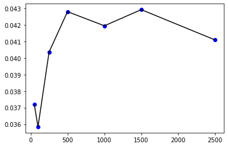

```python
#Step6: Graph the number of tree OOB error rate:

# For Women
oob_error_list_f = [None] * len(n_trees)

# Find OOB error for each forest size:
for i in range(len(n_trees)):
    oob_error_list_f[i] = 1 - rf_f_dict[n_trees[i]].oob_score_
else:
    # Visulaize result:
    plt.plot(n_trees, oob_error_list_f, 'bo',
             n_trees, oob_error_list_f, 'k')

# It is a weird curve, but it looks like 100 trees has the best performance

forest_f = rf_f_dict[100]
```

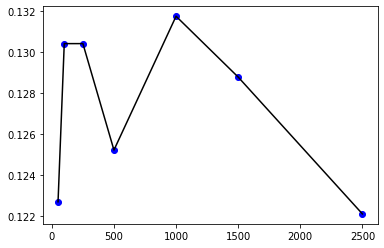

```python
#For Men

oob_error_list = [None] * len(n_trees)

# Find OOB error for each forest size:
for i in range(len(n_trees)):
    oob_error_list[i] = 1 - rf_m_dict[n_trees[i]].oob_score_
else:
    # Visulaize result:
    plt.plot(n_trees, oob_error_list, 'bo',
             n_trees, oob_error_list, 'k')

# A very different tree size impact on the predicting performance.
# The smallest number of trees and biggest are about the same performance.
# I'd go with smaller number of tree as model choice.

forest_m = rf_m_dict[50]
forest_m2 = rf_m_dict[2500]
```

```python
#Step7.1: Evaluate Model - set up test data

#For women
yf_test = pd.DataFrame(df_test['SizeCode'])
Xf_test = pd.DataFrame(df_test[['Height','Weight']])

#For men
ym_test = pd.DataFrame(dm_test['SizeCode'])
Xm_test = pd.DataFrame(dm_test[['Height','Weight']])
```

```python
# Step7.2 -  Evaluate Model: compare predict value with test value

# For Women

yf_pred_rf = pd.DataFrame(forest_f.predict(Xf_test))
yf_pred_size_rf = round(yf_pred_rf,0)

# For Men

ym_pred_rf = pd.DataFrame(forest_m.predict(Xm_test))
ym_pred_size_rf = round(ym_pred_rf,0)
```

```
[Parallel(n_jobs=1)]: Using backend SequentialBackend with 1 concurrent workers.
[Parallel(n_jobs=1)]: Done 100 out of 100 | elapsed:    0.0s finished
[Parallel(n_jobs=1)]: Using backend SequentialBackend with 1 concurrent workers.
[Parallel(n_jobs=1)]: Done  50 out of  50 | elapsed:    0.0s finished
```

**F-1 Score**

|  | Linear Regression | Random Forest |
| --- | --- | --- |
| F-1 Women (micro) | 0.79 | 0.96 |
| F-1 Men (micro) | 0.89 | 0.88 |
| F-1 Women (macro) | 0.41 | 0.96 |
| F-1 Men (macro) | 0.70 | 0.78 |

**Confusion Matrix**

- For Women
- For Men

```python
conf_mat_m_pct_rf = pd.DataFrame(conf_mat_m_rf/conf_mat_m_rf.sum(axis=0))
round(conf_mat_m_pct_rf,2)
```

|  | 0 | 1 | 2 | 3 |
| --- | --- | --- | --- | --- |
| 0 | 0.96 | 0.05 | 0.0 | 0.00 |
| 1 | 0.04 | 0.88 | 0.0 | 0.00 |
| 2 | 0.00 | 0.07 | 1.0 | 0.73 |
| 3 | 0.00 | 0.00 | 0.0 | 0.27 |

```python
conf_mat_f_pct_rf = pd.DataFrame(conf_mat_f_rf/conf_mat_f_rf.sum(axis=1))
round(conf_mat_f_pct_rf,2)
```

|  | 0 | 1 | 2 | 3 | 4 | 5 | 6 |
| --- | --- | --- | --- | --- | --- | --- | --- |
| 0 | 1.0 | 0.00 | 0.00 | 0.00 | 0.00 | 0.00 | 0.00 |
| 1 | 0.0 | 1.00 | 0.00 | 0.00 | 0.00 | 0.00 | 0.00 |
| 2 | 0.0 | 0.24 | 0.93 | 0.00 | 0.00 | 0.00 | 0.00 |
| 3 | 0.0 | 0.00 | 0.00 | 0.98 | 0.02 | 0.00 | 0.00 |
| 4 | 0.0 | 0.00 | 0.00 | 0.02 | 0.94 | 0.00 | 0.14 |
| 5 | 0.0 | 0.00 | 0.00 | 0.00 | 0.00 | 0.98 | 0.03 |
| 6 | 0.0 | 0.00 | 0.00 | 0.00 | 0.00 | 0.00 | 1.00 |

# Findings

Size Ratio from CA 2018 Health Survey Data

|  | XXS | XS | S | M | L | XL | XXL |
| --- | --- | --- | --- | --- | --- | --- | --- |
| Male | 0 | 0 | 29 | 39.2 | 29.6 | 2.3 | 0 |
| Female | 1.3 | 6.6 | 22.5 | 38.9 | 22.1 | 5.1 | 3.4 |

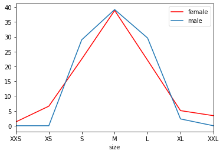

```python
sizeratio = pd.DataFrame({
    'size':["XXS","XS","S","M","L","XL","XXL"],
    'female':[1.3,6.6,22.5,38.9,22.1,5.1,3.4],
    'male':[0,0,29,39.2,29.6,2.3,0]
})
ax = plt.gca()
sizeratio.plot(kind='line', x='size',y='female',color='red',ax=ax)
sizeratio.plot(kind='line', x='size', y='male',ax=ax)

plt.show()
```

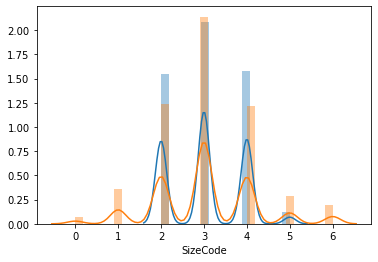

```python
sns.distplot(dfsm_naout['SizeCode'])
sns.distplot(dfsf_naout['SizeCode'])
```

# Next ...

- Model Improvement
  - Complete "off-chart" sizing
  - Increase men's size accuracy

|  | Men | Women |
| --- | --- | --- |
| F-1 (micro) | 0.88 | 0.96 |

- Age Adjustment

| Mean Age | Sample | Population |
| --- | --- | --- |
| Male | 51 | 35 |
| Female | 56 | 37 |
| All | 54 | 36 |

# Size Intelligence

- Market-Specific Sizes
  - Age
  - Race
  - Education etc
- Merchandise Types
  - Footwear
  - Underwear
  - Apparel etc
- Regions and Countries
  - 50 States
  - North America
  - Other Markets

# Q&A

- Data Source
- Data Processing
- Modeling
- Findings
- Next ...

#### >>>>>>> Caliberate **Your Inventory** with **Current Market** Size Ratio <<<<<<<